# Phosphoproteomic Exploratory Analysis

2022-10-20

## Data Description

We are collaborating with a lab that is studying phosphorylation changes during covid infection. This dataset consists of phosphoproteomic TMT mass spec data from 2 10-plexes. We took samples at 0, 5, and 60 minutes post-infection. We also wanted to explore the specific role of 2 genes thought to be used in covid infection, RAB7A and NPC1. To do this, we included cell lines with each of these genes knocked out.

We wanted to have 2 replicates for each condition we were looking at, so we have a total of 3X2X3 or 18 different samples we want to measure. We decide to replicate wild type at 0 minutes in each 10plex for our total 20 wells accross the 2 10-plexes.

## Loading Data

We’re going to load in our data and define the column names we care about. While we could grab these programmatically, it’s safer to explicitly define them so that we always know we’re getting the data we think we’re getting.

## PCA Plots

As an initial quality check, let’s run PCA on our data. We can use `prcomp` to run pca, and `autoplot` to plot the result. Let’s try making 2 pca plots, 1 for each 10plex, colored by condition.

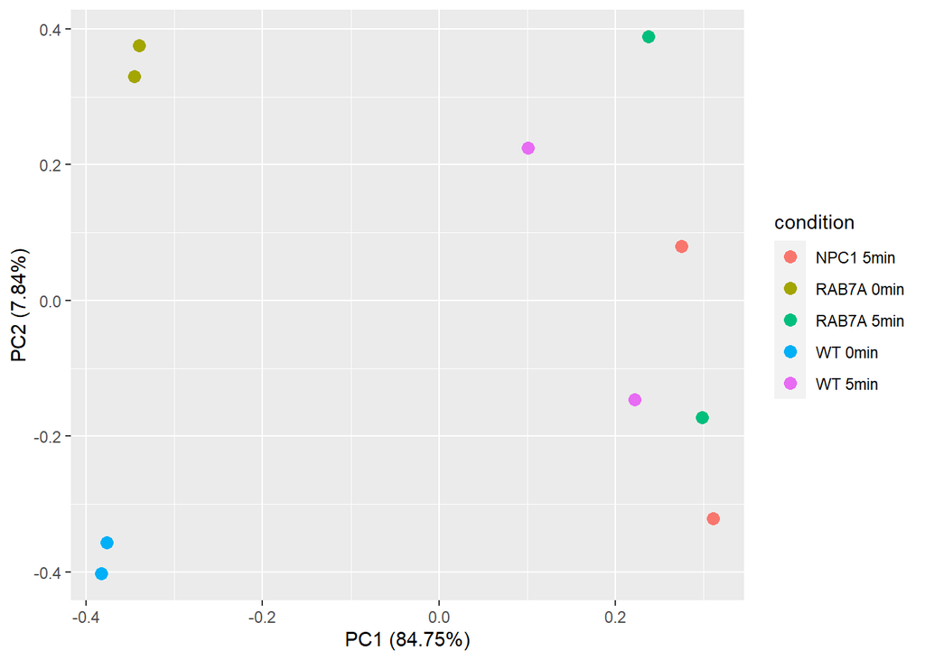

```r
#PCA Plots
plex2_num <- data.frame(t(phos_plex2[,plex2_names]))
pca_res2 <- prcomp(plex2_num, scale = FALSE)
plex2_num$cell.line <- plex2_celllines
plex2_num$time <- plex2_times
plex2_num$condition <- plex2_cond
autoplot(pca_res2, data=plex2_num, colour = 'condition', size=3)
```

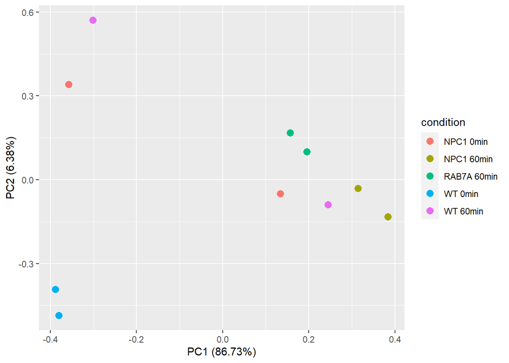

```r
plex3_num <- data.frame(t(phos_plex3[,plex3_names]))
pca_res3 <- prcomp(plex3_num, scale = FALSE)
plex3_num$cell.line <- plex3_celllines
plex3_num$time <- plex3_times
plex3_num$condition <- plex3_cond
autoplot(pca_res3, data=plex3_num, colour = 'condition', size=3)
```

We should look at how our replicates are clustered. Does everything look good in both 10-plexes?